# EDA_FE

```python
import pandas as pd
import numpy as np
import matplotlib.pyplot as plt
import seaborn as sns
import pickle
```

Let's load the Imputed Dataframe to perform further EDA and Feature Engineering.

```python
sampleFile = open("imputed_df","rb")
imputed_df = pickle.load(sampleFile)
sampleFile.close()
```

```python
## Divide the data into train and test set for further investigation and feature exploration
X = imputed_df.drop(['classification'],axis=1)
y = imputed_df['classification']

from sklearn.model_selection import train_test_split
## Dividing the whole dataset into train and test
X_train_cv,X_test,y_train_cv, y_test = train_test_split(X, y, test_size=0.20, random_state=42)
## Dividing the training set again into train and cross-validation
X_train,X_cv,y_train,y_cv = train_test_split(X_train_cv,y_train_cv, test_size=0.20, random_state=42)
```

```python
## Dumping important pieces of data so that it can be used for later purposes.
sampleFile = open("X_train","wb")
pickle.dump(X_train,sampleFile)
sampleFile.close()

sampleFile = open("y_train","wb")
pickle.dump(y_train,sampleFile)
sampleFile.close()

sampleFile = open("X_cv","wb")
pickle.dump(X_cv,sampleFile)
sampleFile.close()

sampleFile = open("y_cv","wb")
pickle.dump(y_cv,sampleFile)
sampleFile.close()

sampleFile = open("X_test","wb")
pickle.dump(X_test,sampleFile)
sampleFile.close()
```

Combined the X_train and y_train to form X_train_df  
Which in turn will help us to perform Exploratory Data Analysis and Feature Engineering

```python
X_train_df = pd.concat([X_train,y_train],axis=1)
```

```python
X_train_df.head(5)
```

|  | id | age | bp | sg | al | su | rbc | pc | pcc | ba | ... | pcv | wc | rc | htn | dm | cad | appet | pe | ane | classification |
| --- | --- | --- | --- | --- | --- | --- | --- | --- | --- | --- | --- | --- | --- | --- | --- | --- | --- | --- | --- | --- | --- |
| 179 | 179 | 72.0 | 90.0 | 1.010 | 2.0 | 0.0 | 1 | 1.0 | present | notpresent | ... | 39 | 8900 | 3.9 | no | no | no | good | no | no | ckd |
| 270 | 270 | 23.0 | 80.0 | 1.025 | 0.0 | 0.0 | 0 | 0.0 | notpresent | notpresent | ... | 41 | 7200 | 5.0 | no | no | no | good | no | no | notckd |
| 323 | 323 | 43.0 | 80.0 | 1.025 | 0.0 | 0.0 | 0 | 0.0 | notpresent | notpresent | ... | 45 | 7800 | 4.5 | no | no | no | good | no | no | notckd |
| 399 | 399 | 58.0 | 80.0 | 1.025 | 0.0 | 0.0 | 0 | 0.0 | notpresent | notpresent | ... | 53 | 6800 | 6.1 | no | no | no | good | no | no | notckd |
| 40 | 40 | 46.0 | 90.0 | 1.010 | 2.0 | 0.0 | 0 | 1.0 | notpresent | notpresent | ... | 32 | 9100 | 4.1 | yes | no | \tno | good | no | no | ckd |

5 rows × 26 columns

```python
len(X_train_df.columns)
```

```
26
```

```python
## Number of features = 25
##Let's do some Univariate Analysis first
```

```python
## High Level Analysis
## Shape of dataframe
X_train_df.shape
```

```
(256, 26)
```

# 1. Univariate Feature Analysis

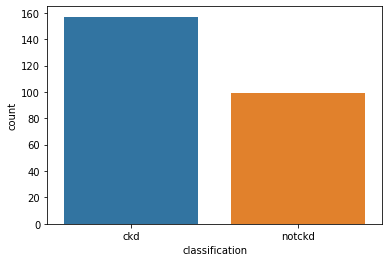

```python
## Distribution of target variable
ax = sns.countplot(x="classification", data=X_train_df)
```

Distribution of target variable seems to fairly balanced.  
Now let's do some Univariate feature analysis.

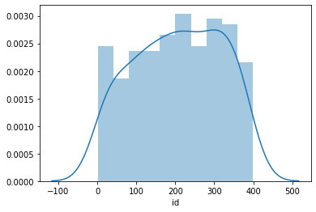

```python
sns.distplot(a = X_train_df['id'],bins = 10)
```

All values are uniformly distributed between 0-400 showing no variance and suggesting that it is a unique identifier.  
Though it was evident from the name of the column itself that it will be an unique identifier but still confirming by plotting or seeing value counts is better.

## 1.1 Analysing feature age

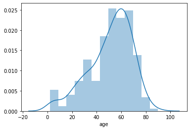

```python
sns.distplot(X_train_df['age'], label = 'class == ckd')
```

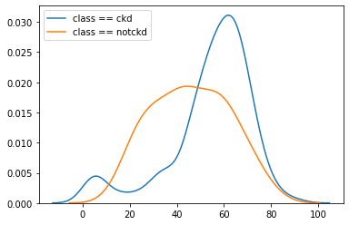

```python
sns.kdeplot(X_train_df.loc[X_train_df['classification'] == 'ckd','age'], label = 'class == ckd')
sns.kdeplot(X_train_df.loc[X_train_df['classification'] == 'notckd','age'], label = 'class == notckd')
```

The above kde plot suggests that people below the age of 40 have less chances of ckd but as a person's age increases there are more chances of a him/her having ckd.  
Adding a new column named target which is nothing but a 0/1 representation of target variable 'classification'

```python
X_train_df['target'] = X_train_df['classification'].apply(lambda x : 1 if x == 'ckd' else 0)
```

```python
X_train_df['target'].head()
X_train_df['target'].value_counts()
```

```
1    157
0     99
Name: target, dtype: int64
```

```python
X_train_df[['age','target']].corr()
```

|  | age | target |
| --- | --- | --- |
| age | 1.000000 | 0.240848 |
| target | 0.240848 | 1.000000 |

Correlation with the target variable is very low.  
Since .corr() checks for linear relationship.  
Let's see what happens if we just bin this feature we have already seen in the kdeplot that the distribution is left skewed.  
Let's divide the feature values into 4 bins

- 0-20
- 20-40
- 40-60
- above 60

```python
def formBinsForAge(x):
  if x <= 20:
    return 0
  elif x > 20 and x <= 40:
    return 1
  elif x > 40 and x <= 60:
    return 2
  elif x > 60:
    return 3
  else:
    return np.nan
```

```python
X_train_df['age_bins'] = X_train_df['age'].apply(lambda x : formBinsForAge(x))
print(X_train_df['age_bins'].value_counts())
X_train_df.head(4)
```

```
2    112
3     85
1     43
0     16
Name: age_bins, dtype: int64
```

|  | id | age | bp | sg | al | su | rbc | pc | pcc | ba | ... | rc | htn | dm | cad | appet | pe | ane | classification | target | age_bins |
| --- | --- | --- | --- | --- | --- | --- | --- | --- | --- | --- | --- | --- | --- | --- | --- | --- | --- | --- | --- | --- | --- |
| 179 | 179 | 72.0 | 90.0 | 1.010 | 2.0 | 0.0 | 1 | 1.0 | present | notpresent | ... | 3.9 | no | no | no | good | no | no | ckd | 1 | 3 |
| 270 | 270 | 23.0 | 80.0 | 1.025 | 0.0 | 0.0 | 0 | 0.0 | notpresent | notpresent | ... | 5.0 | no | no | no | good | no | no | notckd | 0 | 1 |
| 323 | 323 | 43.0 | 80.0 | 1.025 | 0.0 | 0.0 | 0 | 0.0 | notpresent | notpresent | ... | 4.5 | no | no | no | good | no | no | notckd | 0 | 2 |
| 399 | 399 | 58.0 | 80.0 | 1.025 | 0.0 | 0.0 | 0 | 0.0 | notpresent | notpresent | ... | 6.1 | no | no | no | good | no | no | notckd | 0 | 2 |

4 rows × 28 columns

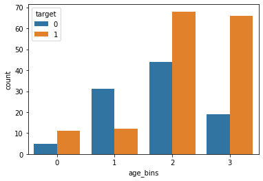

```python
sns.countplot(x = 'age_bins',hue='target',data=X_train_df)
```

Here the information is more clear that the people in the age group of above 60 are prone to chronic kidney disease.

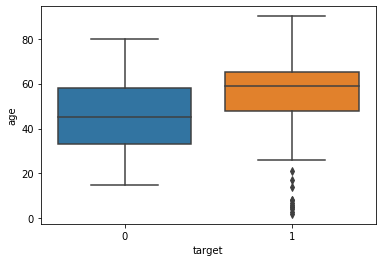

```python
sns.boxplot(x = 'target',y='age',data=X_train_df)
```

Even the boxplots show good seperation capability

## 1.2 Analysing feature blood pressure

```python
X_train_df['bp'].value_counts()
```

```
80.0     83
70.0     71
60.0     48
90.0     29
100.0    17
50.0      4
120.0     1
180.0     1
140.0     1
110.0     1
Name: bp, dtype: int64
```

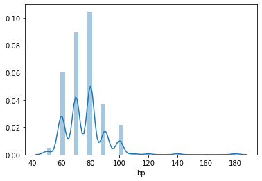

```python
sns.distplot(X_train_df['bp'])
```

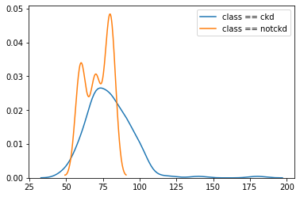

```python
sns.kdeplot(X_train_df.loc[X_train_df['target'] == 1,'bp'], label = 'class == ckd')
sns.kdeplot(X_train_df.loc[X_train_df['target'] == 0,'bp'], label = 'class == notckd')
```

As can be seen from the above plot people with high blood pressure have ckd as compared to people with normal blood pressure range.

```python
def formBPBins(x):
  if x <= 60:
     return 0
  elif x > 60 and x <= 80:
    return 1
  elif x > 80  and x <= 90:
    return 2
  elif x > 90:
    return 3
```

```python
X_train_df['bp_bins'] = X_train_df['bp'].apply(lambda x : formBPBins(x))
```

```python
X_train_df['bp_bins'].value_counts()
```

[output not shown]

[figure not shown]

```python
sns.countplot(x = 'bp_bins',hue='target',data=X_train_df)
```

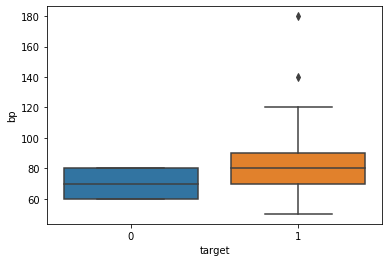

```python
sns.boxplot(x = 'target',y='bp',data=X_train_df)
```

People in the higher blood pressure range are more prone to CKD as compared to lower blood pressure range.

```python
group_df = X_train_df[['age_bins','bp_bins','target']].groupby(['age_bins','bp_bins'])
```

```python
X_train_df[['age_bins','bp']].groupby(['age_bins']).get_group('0').mean()
X_train_df[['age_bins','bp']].groupby(['age_bins']).get_group('0').min()
X_train_df[['age_bins','bp']].groupby(['age_bins']).get_group('0').max()
```

```
age_bins     0.0
bp          80.0
dtype: float64
```

```python
aggFunc = ['mean','max','min','count']
for agg in aggFunc:
  nan_count = 0
  for age_bin in X_train_df['age_bins'].unique():
    try:
      if agg=='mean':
        X_train_df.loc[(X_train_df['age_bins']==str(age_bin)),'age_bp_mean'] = X_train_df[['age_bins','bp']].groupby(['age_bins']).get_group(str(age_bin)).mean()['bp']
      elif agg=='max':
        X_train_df.loc[(X_train_df['age_bins']==str(age_bin)),'age_bp_max'] = X_train_df[['age_bins','bp']].groupby(['age_bins']).get_group(str(age_bin)).max()['bp']
      elif agg=='min':
        X_train_df.loc[(X_train_df['age_bins']==str(age_bin)),'age_bp_min'] = X_train_df[['age_bins','bp']].groupby(['age_bins']).get_group(str(age_bin)).min()['bp']
      elif agg=='count':
        X_train_df.loc[(X_train_df['age_bins']==str(age_bin)),'age_bp_count'] = X_train_df[['age_bins','bp']].groupby(['age_bins']).get_group(str(age_bin)).count()['bp']
    except:
      nan_count += 1
```

```python
print(X_train_df['age_bp_mean'].value_counts())
print(X_train_df['age_bp_max'].value_counts())
print(X_train_df['age_bp_min'].value_counts())
print(X_train_df['age_bp_count'].value_counts())
```

```
78.750000    112
76.470588     85
72.790698     43
68.750000     16
Name: age_bp_mean, dtype: int64
100.0    128
180.0    112
80.0      16
Name: age_bp_max, dtype: int64
50.0    128
60.0    128
Name: age_bp_min, dtype: int64
112.0    112
85.0      85
43.0      43
16.0      16
Name: age_bp_count, dtype: int64
```

Since we are going to develop more features instead of adding them to original dataframe, we'll create separate feature set.

```python
X_train_df.head()
```

|  | id | age | bp | sg | al | su | rbc | pc | pcc | ba | ... | pe | ane | classification | target | age_bins | bp_bins | age_bp_mean | age_bp_max | age_bp_min | age_bp_count |
| --- | --- | --- | --- | --- | --- | --- | --- | --- | --- | --- | --- | --- | --- | --- | --- | --- | --- | --- | --- | --- | --- |
| 179 | 179 | 72.0 | 90.0 | 1.010 | 2.0 | 0.0 | 1 | 1.0 | present | notpresent | ... | no | no | ckd | 1 | 3 | 2 | 76.470588 | 100.0 | 60.0 | 85.0 |
| 270 | 270 | 23.0 | 80.0 | 1.025 | 0.0 | 0.0 | 0 | 0.0 | notpresent | notpresent | ... | no | no | notckd | 0 | 1 | 1 | 72.790698 | 100.0 | 60.0 | 43.0 |
| 323 | 323 | 43.0 | 80.0 | 1.025 | 0.0 | 0.0 | 0 | 0.0 | notpresent | notpresent | ... | no | no | notckd | 0 | 2 | 1 | 78.750000 | 180.0 | 50.0 | 112.0 |
| 399 | 399 | 58.0 | 80.0 | 1.025 | 0.0 | 0.0 | 0 | 0.0 | notpresent | notpresent | ... | no | no | notckd | 0 | 2 | 1 | 78.750000 | 180.0 | 50.0 | 112.0 |
| 40 | 40 | 46.0 | 90.0 | 1.010 | 2.0 | 0.0 | 0 | 1.0 | notpresent | notpresent | ... | no | no | ckd | 1 | 2 | 2 | 78.750000 | 180.0 | 50.0 | 112.0 |

5 rows × 33 columns

```python
feature_df = pd.DataFrame()
feature_df['target'] = X_train_df['target']
feature_df['age_bins'] = X_train_df['age_bins']
feature_df['bp_bins'] = X_train_df['bp_bins']
feature_df['age_bp_mean'] = X_train_df['age_bp_mean']
feature_df['age_bp_max'] = X_train_df['age_bp_max']
feature_df['age_bp_min'] = X_train_df['age_bp_min']
feature_df['age_bp_count'] = X_train_df['age_bp_count']
```

```python
X_train_df.drop(['target','age_bins','bp_bins','age_bp_mean','age_bp_max','age_bp_min','age_bp_count'],axis=1,inplace = True)
X_train_df.head()
```

|  | id | age | bp | sg | al | su | rbc | pc | pcc | ba | ... | pcv | wc | rc | htn | dm | cad | appet | pe | ane | classification |
| --- | --- | --- | --- | --- | --- | --- | --- | --- | --- | --- | --- | --- | --- | --- | --- | --- | --- | --- | --- | --- | --- |
| 179 | 179 | 72.0 | 90.0 | 1.010 | 2.0 | 0.0 | 1 | 1.0 | present | notpresent | ... | 39 | 8900 | 3.9 | no | no | no | good | no | no | ckd |
| 270 | 270 | 23.0 | 80.0 | 1.025 | 0.0 | 0.0 | 0 | 0.0 | notpresent | notpresent | ... | 41 | 7200 | 5.0 | no | no | no | good | no | no | notckd |
| 323 | 323 | 43.0 | 80.0 | 1.025 | 0.0 | 0.0 | 0 | 0.0 | notpresent | notpresent | ... | 45 | 7800 | 4.5 | no | no | no | good | no | no | notckd |
| 399 | 399 | 58.0 | 80.0 | 1.025 | 0.0 | 0.0 | 0 | 0.0 | notpresent | notpresent | ... | 53 | 6800 | 6.1 | no | no | no | good | no | no | notckd |
| 40 | 40 | 46.0 | 90.0 | 1.010 | 2.0 | 0.0 | 0 | 1.0 | notpresent | notpresent | ... | 32 | 9100 | 4.1 | yes | no | \tno | good | no | no | ckd |

5 rows × 26 columns

```python
feature_df.head()
```

|  | target | age_bins | bp_bins | age_bp_mean | age_bp_max | age_bp_min | age_bp_count |
| --- | --- | --- | --- | --- | --- | --- | --- |
| 179 | 1 | 3 | 2 | 76.470588 | 100.0 | 60.0 | 85.0 |
| 270 | 0 | 1 | 1 | 72.790698 | 100.0 | 60.0 | 43.0 |
| 323 | 0 | 2 | 1 | 78.750000 | 180.0 | 50.0 | 112.0 |
| 399 | 0 | 2 | 1 | 78.750000 | 180.0 | 50.0 | 112.0 |
| 40 | 1 | 2 | 2 | 78.750000 | 180.0 | 50.0 | 112.0 |

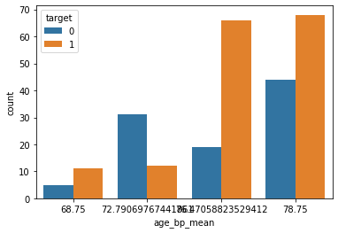

```python
sns.countplot(x = 'age_bp_mean',hue='target',data=feature_df)
```

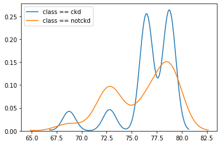

```python
sns.kdeplot(feature_df.loc[feature_df['target'] == 1,'age_bp_mean'], label = 'class == ckd')
sns.kdeplot(feature_df.loc[feature_df['target'] == 0,'age_bp_mean'], label = 'class == notckd')
```

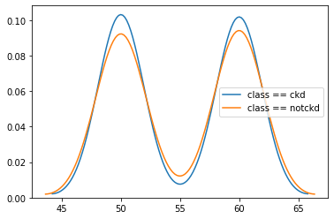

```python
sns.kdeplot(feature_df.loc[feature_df['target'] == 1,'age_bp_min'], label = 'class == ckd')
sns.kdeplot(feature_df.loc[feature_df['target'] == 0,'age_bp_min'], label = 'class == notckd')
```

This feature won't be of any use.  
Even max count gives similar result.

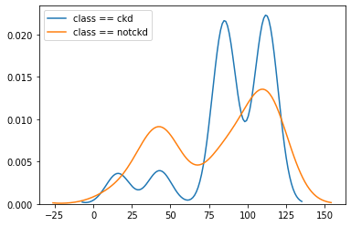

```python
sns.kdeplot(feature_df.loc[feature_df['target'] == 1,'age_bp_count'], label = 'class == ckd')
sns.kdeplot(feature_df.loc[feature_df['target'] == 0,'age_bp_count'], label = 'class == notckd')
```

```python
feature_df['age_bins'] = feature_df['age_bins'].apply(lambda x : str(x))
```

```python
abs(feature_df.corr()['target'])
```

```
target          1.000000
bp_bins         0.371661
age_bp_mean     0.117615
age_bp_max      0.015384
age_bp_min      0.008021
age_bp_count    0.133578
Name: target, dtype: float64
```

## 1.3 Analysing feature Specific Gravity(Sg)

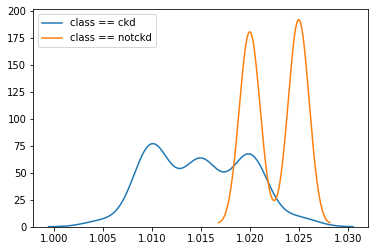

```python
sns.kdeplot(X_train_df.loc[X_train_df['classification'] == 'ckd','sg'], label = 'class == ckd')
sns.kdeplot(X_train_df.loc[X_train_df['classification'] == 'notckd','sg'], label = 'class == notckd')
```

```python
X_train_df['target'] = feature_df['target']
```

Since going through each and every feature will be cumbersome.  
It's better that I filter few features and start building on those features.

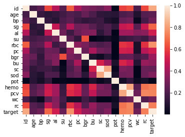

```python
sns.heatmap(abs(X_train_df.corr()))
```

```python
abs(X_train_df.corr()['target'])
```

```
id        0.829134
age       0.240848
bp        0.280729
sg        0.678348
al        0.507968
su        0.273448
rbc       0.775688
pc        0.510749
bgr       0.383836
bu        0.353857
sc        0.258217
sod       0.322329
pot       0.010682
hemo      0.732390
pcv       0.748686
wc        0.279009
rc        0.733150
target    1.000000
Name: target, dtype: float64
```

```python
corr_ser = X_train_df.corr()['target']
corr_ser[corr_ser >= 0.4]
```

```
al        0.507968
rbc       0.775688
pc        0.510749
target    1.000000
Name: target, dtype: float64
```

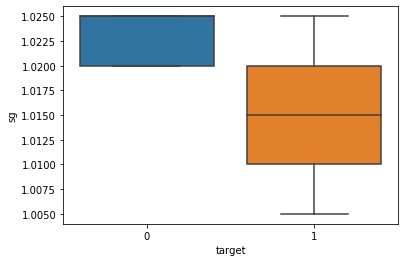

```python
sns.boxplot(X_train_df['target'],X_train_df['sg'])
```

```python
X_train_df['sg'].describe()
```

```
count    256.000000
mean       1.017871
std        0.005518
min        1.005000
25%        1.015000
50%        1.020000
75%        1.020000
max        1.025000
Name: sg, dtype: float64
```

Checked on the internet that specific gravity of urine is an important factor in determining the chronic renal failure

## 1.4 Analysing feature AL(Albumin)

```python
X_train_df['al'].describe()
```

```
count    256.000000
mean       0.812500
std        1.272638
min        0.000000
25%        0.000000
50%        0.000000
75%        1.000000
max        5.000000
Name: al, dtype: float64
```

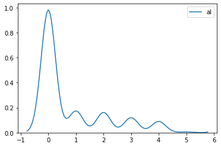

```python
sns.kdeplot(X_train_df['al'])
```

It shows that distribution of albumin is right skewed.  
Lesser number of people have high albumin levels

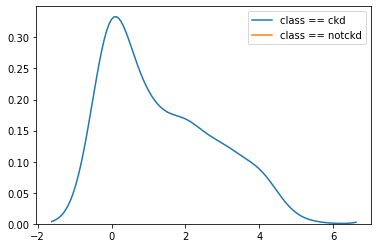

```python
sns.kdeplot(X_train_df.loc[X_train_df['target'] == 1,'al'], label = 'class == ckd')
sns.kdeplot(X_train_df.loc[X_train_df['target'] == 0,'al'], label = 'class == notckd')
```

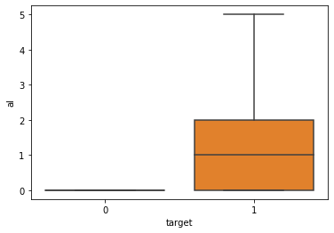

```python
sns.boxplot(x=X_train_df['target'],y=X_train_df['al'])
```

```python
def formAlBins(x):
  if x == 0:
    return 0
  elif x >=1 and x <=2:
    return 1
  else:
    return 2

feature_df['al_cat'] = X_train_df['al'].apply(lambda x : formAlBins(x))
```

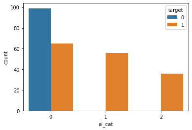

```python
sns.countplot(x='al_cat',hue='target',data=feature_df)
```

```python
feature_df[['al_cat','target']].corr()
```

|  | al_cat | target |
| --- | --- | --- |
| al_cat | 1.000000 | 0.544739 |
| target | 0.544739 | 1.000000 |

Forming bins has increased the correlation between albumin and target from 0.50 to 0.54

## 1.5 Analysing feature su(Sugar)

```python
X_train_df['su'].value_counts()
```

```
0.0    222
1.0     10
2.0      8
3.0      8
4.0      6
5.0      2
Name: su, dtype: int64
```

```python
# Facing error while running this cell
#sns.kdeplot(X_train_df.loc[X_train_df['target'] == 1,'su'],label='class=ckd')
#sns.kdeplot(X_train_df.loc[X_train_df['target'] == 0,'su'],label='class=notckd')
```

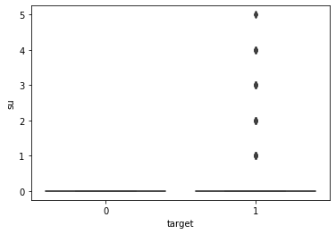

```python
sns.boxplot(X_train_df['target'],X_train_df['su'])
```

```python
X_train_df['su'].value_counts()
```

```
0.0    222
1.0     10
2.0      8
3.0      8
4.0      6
5.0      2
Name: su, dtype: int64
```

Form two bins :  
su - 0  
su - 1

```python
feature_df['su_bin'] = X_train_df['su'].apply(lambda x : 0 if x==0 else 1)
```

## 1.6 Analysis of feature BGR(Blood Glucose Random)

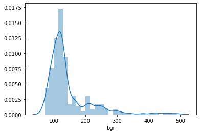

```python
sns.distplot(X_train_df['bgr'],label='distribution plot of bgr')
```

It's right skewed

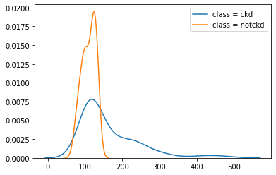

```python
sns.kdeplot(X_train_df.loc[X_train_df['target']==1,'bgr'],label='class = ckd')
sns.kdeplot(X_train_df.loc[X_train_df['target']==0,'bgr'],label='class = notckd')
```

```python
q = np.percentile(X_train_df[~X_train_df['bgr'].isnull() & (X_train_df['target'] == 0)]['bgr'],q=[75,90,99])
q
```

```
array([125.  , 131.2 , 139.02])
```

So in the above piece of code,I am trying to find out the quantiles for 'blood group random' with target = 0("Not Ckd")  
Since we can see lower value of blood group random to not have ckd, we can clearly form two groups based on tha above observation.  
One for the "notCkd" class and other for ckd class

```python
feature_df['bgr_bin'] = X_train_df['bgr'].apply(lambda x : 0 if x <= 140 else 1)
```

```python
abs(feature_df[['bgr_bin','target']].corr())
```

|  | bgr_bin | target |
| --- | --- | --- |
| bgr_bin | 1.00000 | 0.48236 |
| target | 0.48236 | 1.00000 |

```python
feature_df.head()
```

|  | target | age_bins | bp_bins | age_bp_mean | age_bp_max | age_bp_min | age_bp_count | al_cat | su_bin | bgr_bin |
| --- | --- | --- | --- | --- | --- | --- | --- | --- | --- | --- |
| 179 | 1 | 3 | 2 | 76.470588 | 100.0 | 60.0 | 85.0 | 1 | 0 | 0 |
| 270 | 0 | 1 | 1 | 72.790698 | 100.0 | 60.0 | 43.0 | 0 | 0 | 0 |
| 323 | 0 | 2 | 1 | 78.750000 | 180.0 | 50.0 | 112.0 | 0 | 0 | 0 |
| 399 | 0 | 2 | 1 | 78.750000 | 180.0 | 50.0 | 112.0 | 0 | 0 | 0 |
| 40 | 1 | 2 | 2 | 78.750000 | 180.0 | 50.0 | 112.0 | 1 | 0 | 0 |

## 1.7 Analysing feature bu

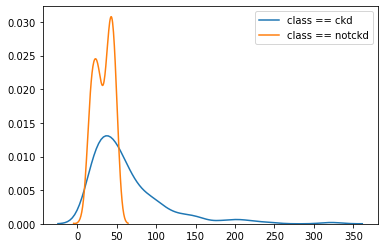

```python
## Let's look at feature bu
sns.kdeplot(X_train_df.loc[X_train_df['target'] == 1,'bu'], label = 'class == ckd')
sns.kdeplot(X_train_df.loc[X_train_df['target'] == 0,'bu'], label = 'class == notckd')
```

```python
from scipy.stats import spearmanr
spearmanr(X_train_df['bu'],X_train_df['target'])
```

```
SpearmanrResult(correlation=0.38072603708044706, pvalue=2.9632239551884964e-10)
```

```python
X_train_df[['bu','target']].corr()
```

|  | bu | target |
| --- | --- | --- |
| bu | 1.000000 | 0.353857 |
| target | 0.353857 | 1.000000 |

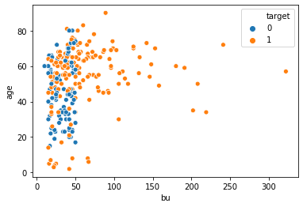

```python
sns.scatterplot('bu','age',hue = 'target',data = X_train_df)
```

With blood urea values less than 50,number of CKD cases are comparitively less as compared to NotCKD cases.  
BloodUrea along with Age doesn't prove to be useful in forming binary features or any sort of features.

```python
## Coming up with the border value for creating binary bins
q = np.percentile(X_train_df[X_train_df['target'] == 0]['bu'],q=[75,90,99])
print(q)
```

```
[43. 48. 50.]
```

```python
feature_df['bu_bin'] = X_train_df['bu'].apply(lambda x : 0 if x <= 50 else 1)
feature_df['bu_bin'].value_counts()
```

```
0    179
1     77
Name: bu_bin, dtype: int64
```

```python
feature_df.head()
```

|  | target | age_bins | bp_bins | age_bp_mean | age_bp_max | age_bp_min | age_bp_count | al_cat | su_bin | bgr_bin | bu_bin |
| --- | --- | --- | --- | --- | --- | --- | --- | --- | --- | --- | --- |
| 179 | 1 | 3 | 2 | 76.470588 | 100.0 | 60.0 | 85.0 | 1 | 0 | 0 | 1 |
| 270 | 0 | 1 | 1 | 72.790698 | 100.0 | 60.0 | 43.0 | 0 | 0 | 0 | 0 |
| 323 | 0 | 2 | 1 | 78.750000 | 180.0 | 50.0 | 112.0 | 0 | 0 | 0 | 0 |
| 399 | 0 | 2 | 1 | 78.750000 | 180.0 | 50.0 | 112.0 | 0 | 0 | 0 | 0 |
| 40 | 1 | 2 | 2 | 78.750000 | 180.0 | 50.0 | 112.0 | 1 | 0 | 0 | 1 |

```python
feature_df[['bu_bin','target']].corr()['bu_bin']
```

```
bu_bin    1.000000
target    0.520819
Name: bu_bin, dtype: float64
```

```python
spearmanr(feature_df['bu_bin'],feature_df['target'])
```

```
SpearmanrResult(correlation=0.5208187587660582, pvalue=3.3517945961596853e-19)
```

p-value is less than significance level and therefore the null hypothesis that attributes are independent is rejected and the alternate hypothesis that there is some correlation between the two attributes is not rejected.  
Also the correlation coefficient has been increased significantly after forming binary features with bu

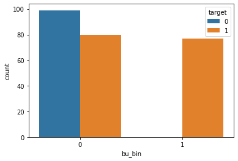

```python
sns.countplot(x='bu_bin',hue='target',data=feature_df)
```

```python
X_train_df.select_dtypes(include=['float64','int64']).columns
```

[output not shown]